# Coursera ML Project

William Knapp

The data analyzed and interpreted herein come from the http://groupware.les.inf.puc-rio.br/har project.

# Reading in the data and examining it for problems

```r
dat<-read.csv("pml-training.csv")
```

After looking at the data structure, with data(str), it’s clear that there are a number of variables that contain “NA”, “”, or “#DIV/0!” values. To avoid reading in integer variables as factors, let’s reread in the data and specify what the na.strings are.

```r
dat<-read.csv("pml-training.csv", na.strings=c("NA","na","","#DIV/0!"))
str(dat,list.len=length(dat))
```

[output not shown]

[output cut: 146 more lines]

I’d really like to avoid imputing missing values, so I’m going to see what the effects of removing any cases that are incomplete and removing any columns that are incomplete would have.

```r
sum(complete.cases(dat))
```

```
## [1] 0
```

As there are no observations with complete cases, dropping rows without complete cases would leave us nothing in our training set, so that’s not a feasible solution.

Let’s check on how many rows have NA values, hopefully we’ll have significantly more than 0, which would allow us to drop those rows and run our learning algorithms on the remaining rows without NA values.

```r
hasna=0
for(i in 1:length(dat)){
    if(sum(is.na(dat[i]) + length(dat[i][]))) hasna = hasna+1
}
hasna
```

```
## [1] 160
```

```r
training<-dat[1]
dfindex=1;
for(i in 2:length(dat)){
    if(sum(is.na(dat[i]))==0){
        dfindex = dfindex + 1
        training[dfindex]=dat[i]
    }
}
#If anyone knows a better way of doing this without a for loop. Please comment
#my project.
```

This leaves us with 59 features ,but I don’t think the first several features will be useful for classification so I’m omitting them from the training sets.

```r
training<-training[,-(1:7)]
```

That leaves us 52 features. I’ll break my training data into training and testing sets. I’ll use the testing subset to cross-validate my model and estimate the out of sample error.

```r
temp<-training
library(caret)
set.seed(2134)
inTrain = createDataPartition(temp$classe, p = 3/4)[[1]]
training = temp[ inTrain,]
testing = temp[-inTrain,]
```

Let’s see if any variables have near zero variability that we could get rid of.

```r
sum(nearZeroVar(training,saveMetrics=TRUE)$nzv)
```

```
## [1] 0
```

There are none but let’s try to reduce the complexity of the dataset using principal components analysis. Because we have negative feature values we probably should not take the logs of the training features.

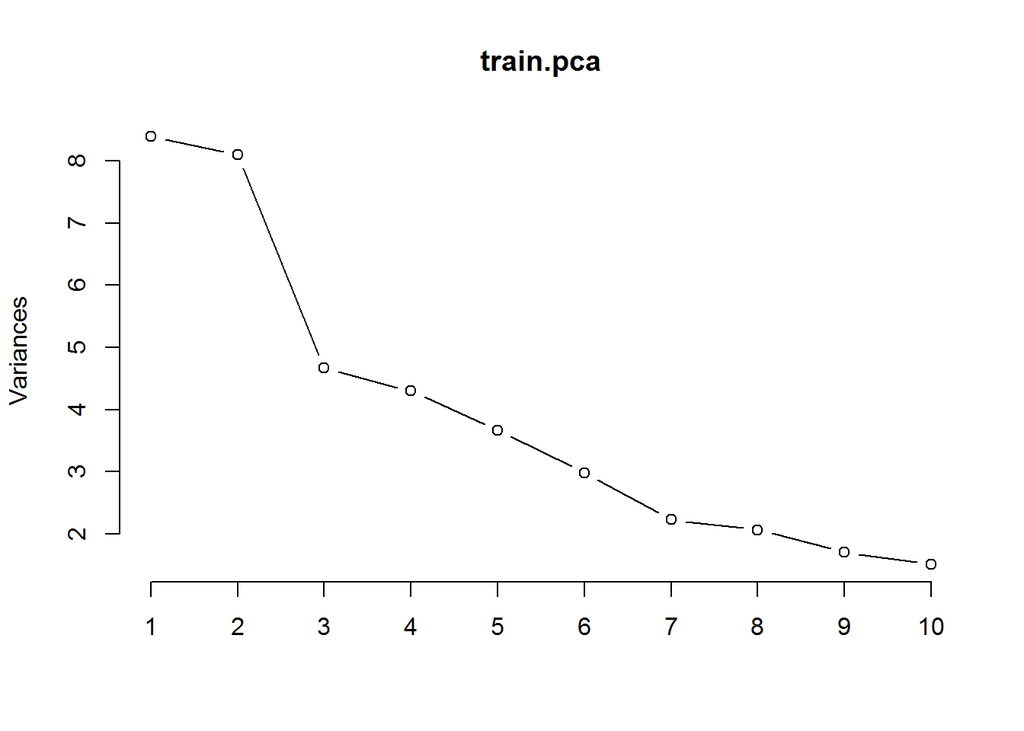

```r
train.pca<-prcomp(training[,-(length(training))],center=TRUE,scale.=TRUE)
plot(train.pca, type='l')
```

Analysis of the scree plot suggests we should keep the first 7 components, but I’d like to keep any variables that explain at least 2.5% of the variance.

```r
summary(train.pca)
```

```
## Importance of components:
##                           PC1    PC2     PC3    PC4     PC5     PC6
## Standard deviation     2.8955 2.8443 2.15949 2.0725 1.91431 1.72705
## Proportion of Variance 0.1612 0.1556 0.08968 0.0826 0.07047 0.05736
## Cumulative Proportion  0.1612 0.3168 0.40649 0.4891 0.55957 0.61693
##                            PC7     PC8     PC9   PC10    PC11    PC12
## Standard deviation     1.49304 1.43690 1.30697 1.2280 1.17635 1.05468
## Proportion of Variance 0.04287 0.03971 0.03285 0.0290 0.02661 0.02139
## Cumulative Proportion  0.65980 0.69950 0.73235 0.7613 0.78796 0.80936
##                           PC13    PC14    PC15    PC16    PC17   PC18
## Standard deviation     0.99342 0.94453 0.90478 0.88806 0.82235 0.7597
## Proportion of Variance 0.01898 0.01716 0.01574 0.01517 0.01301 0.0111
## Cumulative Proportion  0.82833 0.84549 0.86123 0.87640 0.88941 0.9005
##                           PC19    PC20    PC21    PC22    PC23    PC24
## Standard deviation     0.72425 0.68760 0.64400 0.62967 0.60814 0.58038
## Proportion of Variance 0.01009 0.00909 0.00798 0.00762 0.00711 0.00648
## Cumulative Proportion  0.91059 0.91968 0.92766 0.93528 0.94240 0.94887
##                           PC25    PC26    PC27    PC28   PC29    PC30
## Standard deviation     0.55563 0.54611 0.50379 0.48965 0.4502 0.43365
## Proportion of Variance 0.00594 0.00574 0.00488 0.00461 0.0039 0.00362
## Cumulative Proportion  0.95481 0.96055 0.96543 0.97004 0.9739 0.97755
##                           PC31    PC32    PC33    PC34    PC35    PC36
## Standard deviation     0.39210 0.36358 0.34635 0.33481 0.30354 0.28324
## Proportion of Variance 0.00296 0.00254 0.00231 0.00216 0.00177 0.00154
## Cumulative Proportion  0.98051 0.98305 0.98536 0.98751 0.98928 0.99083
##                           PC37    PC38    PC39    PC40    PC41    PC42
## Standard deviation     0.25361 0.23705 0.23450 0.20120 0.19387 0.18509
## Proportion of Variance 0.00124 0.00108 0.00106 0.00078 0.00072 0.00066
## Cumulative Proportion  0.99206 0.99315 0.99420 0.99498 0.99570 0.99636
##                           PC43    PC44    PC45    PC46    PC47    PC48
## Standard deviation     0.18116 0.17031 0.16643 0.16544 0.14663 0.14165
## Proportion of Variance 0.00063 0.00056 0.00053 0.00053 0.00041 0.00039
## Cumulative Proportion  0.99699 0.99755 0.99808 0.99861 0.99902 0.99941
##                           PC49    PC50    PC51    PC52
## Standard deviation     0.11438 0.09764 0.07693 0.04621
## Proportion of Variance 0.00025 0.00018 0.00011 0.00004
## Cumulative Proportion  0.99966 0.99985 0.99996 1.00000
```

If we’re going to keep the components that explain 2.5% of the variance, we’ll retain the first 11 components.

# Random Forest Model

Let’s preprocess our data using these components and use random forests as our learning algorithm.

```r
preProc<-preProcess(training[,-length(training)], method="pca", pcaComp=11)
trainPC<-predict(preProc,training[,-length(training)])
trainPC<-data.frame(trainPC, classe=training$classe)
rffit<-train(classe~.,method="rf",data=trainPC, proxy=TRUE)
confusionMatrix(training$classe,predict(rffit,trainPC))
```

```
## Confusion Matrix and Statistics
##
##           Reference
## Prediction    A    B    C    D    E
##          A 4185    0    0    0    0
##          B    0 2848    0    0    0
##          C    0    0 2567    0    0
##          D    0    0    0 2412    0
##          E    0    0    0    0 2706
##
## Overall Statistics
##
##                Accuracy : 1
##                  95% CI : (0.9997, 1)
##     No Information Rate : 0.2843
##     P-Value [Acc > NIR] : < 2.2e-16
##
##                   Kappa : 1
##  Mcnemar's Test P-Value : NA
##
## Statistics by Class:
##
##                      Class: A Class: B Class: C Class: D Class: E
## Sensitivity            1.0000   1.0000   1.0000   1.0000   1.0000
## Specificity            1.0000   1.0000   1.0000   1.0000   1.0000
## Pos Pred Value         1.0000   1.0000   1.0000   1.0000   1.0000
## Neg Pred Value         1.0000   1.0000   1.0000   1.0000   1.0000
## Prevalence             0.2843   0.1935   0.1744   0.1639   0.1839
## Detection Rate         0.2843   0.1935   0.1744   0.1639   0.1839
## Detection Prevalence   0.2843   0.1935   0.1744   0.1639   0.1839
## Balanced Accuracy      1.0000   1.0000   1.0000   1.0000   1.0000
```

From examining the confusion matrix, we can see that the model perfectly predicts the class of exercise from the first 11 principle components.

Now let’s cross validate with our test set and estimate our out of sample error.

```r
testPC<-predict(preProc,testing[,-length(testing)])
confusionMatrix(testing$classe,predict(rffit,testPC))
```

```
## Confusion Matrix and Statistics
##
##           Reference
## Prediction    A    B    C    D    E
##          A 1356    7   21   11    0
##          B   34  886   22    5    2
##          C   12   10  822   11    0
##          D    5    6   57  736    0
##          E    2    9    6    4  880
##
## Overall Statistics
##
##                Accuracy : 0.9543
##                  95% CI : (0.9481, 0.96)
##     No Information Rate : 0.2873
##     P-Value [Acc > NIR] : < 2.2e-16
##
##                   Kappa : 0.9422
##  Mcnemar's Test P-Value : 5.57e-12
##
## Statistics by Class:
##
##                      Class: A Class: B Class: C Class: D Class: E
## Sensitivity            0.9624   0.9651   0.8858   0.9596   0.9977
## Specificity            0.9888   0.9842   0.9917   0.9836   0.9948
## Pos Pred Value         0.9720   0.9336   0.9614   0.9154   0.9767
## Neg Pred Value         0.9849   0.9919   0.9738   0.9924   0.9995
## Prevalence             0.2873   0.1872   0.1892   0.1564   0.1799
## Detection Rate         0.2765   0.1807   0.1676   0.1501   0.1794
## Detection Prevalence   0.2845   0.1935   0.1743   0.1639   0.1837
## Balanced Accuracy      0.9756   0.9747   0.9387   0.9716   0.9963
```

# Boosting Model

Let’s see if we can do any better with boosting.

```r
boostfit<-train(classe~., method="gbm",data=trainPC, verbose=FALSE)
confusionMatrix(training$classe,predict(boostfit,trainPC))
```

```
## Confusion Matrix and Statistics
##
##           Reference
## Prediction    A    B    C    D    E
##          A 3590  112  189  236   58
##          B  296 2025  277  129  121
##          C  276  138 2017   66   70
##          D  159  100  246 1856   51
##          E  184  210  235  140 1937
##
## Overall Statistics
##
##                Accuracy : 0.7763
##                  95% CI : (0.7694, 0.783)
##     No Information Rate : 0.3061
##     P-Value [Acc > NIR] : < 2.2e-16
##
##                   Kappa : 0.7164
##  Mcnemar's Test P-Value : < 2.2e-16
##
## Statistics by Class:
##
##                      Class: A Class: B Class: C Class: D Class: E
## Sensitivity            0.7969   0.7834   0.6805   0.7647   0.8659
## Specificity            0.9417   0.9322   0.9532   0.9548   0.9384
## Pos Pred Value         0.8578   0.7110   0.7857   0.7695   0.7158
## Neg Pred Value         0.9131   0.9528   0.9221   0.9536   0.9750
## Prevalence             0.3061   0.1756   0.2014   0.1649   0.1520
## Detection Rate         0.2439   0.1376   0.1370   0.1261   0.1316
## Detection Prevalence   0.2843   0.1935   0.1744   0.1639   0.1839
## Balanced Accuracy      0.8693   0.8578   0.8169   0.8597   0.9021
```

This method is much less accurate, so I’ll stick with the random forest model on the true testing data.

```r
testdat<-dat<-read.csv("pml-testing.csv", na.strings=c("NA","na","","#DIV/0!"))
testdatPC<-predict(preProc,testdat)
predictions<-predict(rffit,testdatPC)
```

Finally, lets use the function provided in the instructions to create files to submit our predictions on the 20 sample test set.

```r
pml_write_files = function(x){
  n = length(x)
  for(i in 1:n){
    filename = paste0("problem_id_",i,".txt")
    write.table(x[i],file=filename,quote=FALSE,row.names=FALSE,col.names=FALSE)
  }
}

pml_write_files(predictions)
```